# City tourism and hotel occupancy dynamics

Avidrita Mallick

2026-11-19

## City Tourism and Hotel Occupancy Dynamics

## 1. Introduction

Tourism plays an important role in the economic development of a city. It creates employment opportunities and supports the hotel, transport and hospitality industries.

This project studies tourist arrivals and hotel occupancy dynamics in Kolkata, Delhi and Jaipur. It uses descriptive analytics to understand tourism patterns, seasonal changes, hotel occupancy rates and average room prices.

## 2. Problem Statement

Tourist arrivals and hotel occupancy may change from one city to another and across different seasons. This project examines these changes to understand the relationship between tourism demand and hotel performance.

## 3. Objectives

- To compare tourist arrivals across three cities.
- To analyse domestic and international tourist arrivals.
- To study seasonal tourism patterns.
- To compare hotel occupancy rates.
- To examine average hotel room prices.
- To identify useful patterns through graphs and statistics.

## 4. Scope of the Study

The study covers Kolkata, Delhi and Jaipur using a small sample dataset for selected months of 2025. The analysis focuses on tourism arrivals, hotel rooms, occupancy rates and average room prices.

## 5. Type of Analytics

This project uses Descriptive Analytics. Descriptive analytics summarises historical data using tables, statistical measures and visualisations.

```r
library(readr)

# Import the dataset
data <- read_csv(
  "Small_City_Tourism_Hotel_Occupancy_Dataset.csv",
  show_col_types = FALSE
)

# Correct city and season names
data$City <- tools::toTitleCase(
  tolower(trimws(data$City))
)

data$Season <- tools::toTitleCase(
  tolower(trimws(data$Season))
)

# Display first six records
head(data)
```

```
## # A tibble: 6 × 11
##   Month    City    Season   Domestic_Tourist_Arrivals International_Tourist_Ar…¹
##   <chr>    <chr>   <chr>                        <dbl>                      <dbl>
## 1 Jan-2025 Kolkata Winter                      150000                      18000
## 2 Feb-2025 Kolkata Winter                      142000                      17000
## 3 Apr-2025 Kolkata Spring                      138000                      16000
## 4 Jul-2025 Kolkata Monsoon                     105000                      12000
## 5 Oct-2025 Kolkata Festival                    165000                      21000
## 6 Jan-2025 Delhi   Winter                      310000                      60000
## # ℹ abbreviated name: ¹International_Tourist_Arrivals
## # ℹ 6 more variables: Total_Tourist_Arrivals <dbl>,
## #   Available_Hotel_Rooms <dbl>, Hotel_Occupancy_Rate_Percent <dbl>,
## #   Average_Hotel_Room_Price_INR <dbl>, Estimated_Occupied_Rooms <dbl>,
## #   Tourism_Demand_Level <chr>
```

## 7. Descriptive Statistical Analysis

```r
# Average tourist arrivals
mean(data$Total_Tourist_Arrivals)
```

```
## [1] 238333.3
```

```r
# Median tourist arrivals
median(data$Total_Tourist_Arrivals)
```

```
## [1] 225000
```

```r
# Minimum tourist arrivals
min(data$Total_Tourist_Arrivals)
```

```
## [1] 117000
```

```r
# Maximum tourist arrivals
max(data$Total_Tourist_Arrivals)
```

```
## [1] 405000
```

```r
# Average hotel occupancy rate
mean(data$Hotel_Occupancy_Rate_Percent)
```

```
## [1] 73.4
```

```r
# Average hotel room price
mean(data$Average_Hotel_Room_Price_INR)
```

```
## [1] 3466.667
```

## 8. City-wise Tourist Arrival Analysis

Definition: City-wise analysis compares the total number of tourists visiting each city.

```r
city_arrivals <- aggregate(
  Total_Tourist_Arrivals ~ City,
  data = data,
  FUN = sum
)

knitr::kable(city_arrivals)
```

| City | Total_Tourist_Arrivals |
| --- | --- |
| Delhi | 1714000 |
| Jaipur | 1077000 |
| Kolkata | 784000 |

### Graph: City-wise tourist arrivals

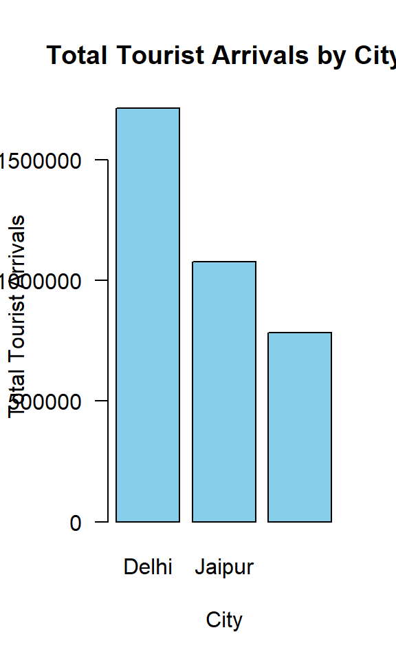

```r
barplot(
  city_arrivals$Total_Tourist_Arrivals,
  names.arg = city_arrivals$City,
  col = "skyblue",
  main = "Total Tourist Arrivals by City",
  xlab = "City",
  ylab = "Total Tourist Arrivals",
  las = 1
)
```

## 9. Seasonal Tourism Analysis Definition: Seasonal analysis studies how tourist arrivals change during different seasons.

```r
season_arrivals <- aggregate(
  Total_Tourist_Arrivals ~ Season,
  data = data,
  FUN = sum
)

knitr::kable(season_arrivals)
```

| Season | Total_Tourist_Arrivals |
| --- | --- |
| Festival | 856000 |
| Monsoon | 522000 |
| Spring | 685000 |
| Winter | 1512000 |

### Graph: Seasonal tourist arrivals

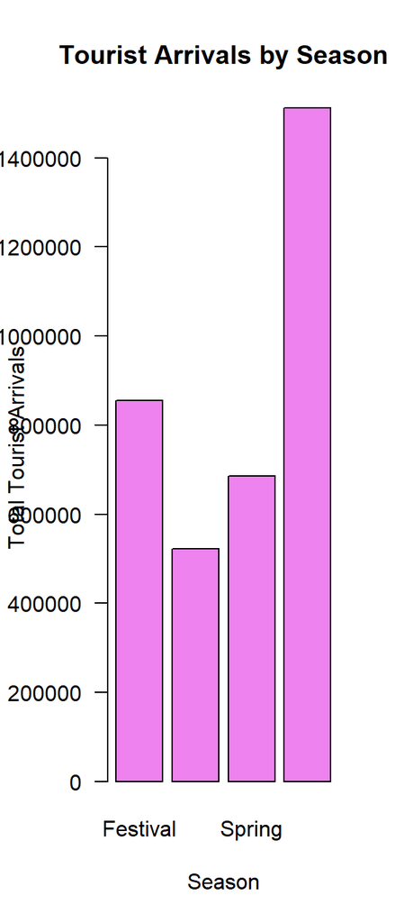

```r
barplot(
  season_arrivals$Total_Tourist_Arrivals,
  names.arg = season_arrivals$Season,
  col = "violet",
  main = "Tourist Arrivals by Season",
  xlab = "Season",
  ylab = "Total Tourist Arrivals",
  las = 1
)
```

## 10. Hotel Occupancy Analysis

```r
# Calculate average occupancy rate for each city

city_occupancy <- aggregate(
  Hotel_Occupancy_Rate_Percent ~ City,
  data = data,
  FUN = mean
)

# Display the table
knitr::kable(city_occupancy, digits = 2)
```

| City | Hotel_Occupancy_Rate_Percent |
| --- | --- |
| Delhi | 75.6 |
| Jaipur | 73.0 |
| Kolkata | 71.6 |

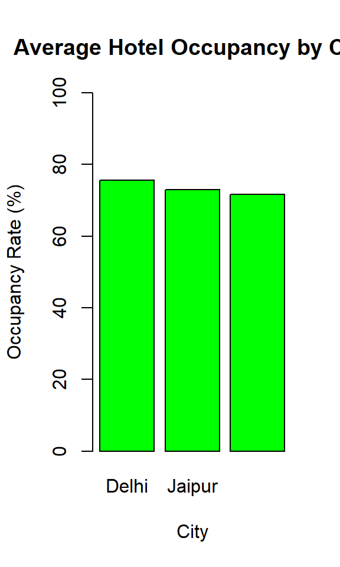

```r
barplot(
  city_occupancy$Hotel_Occupancy_Rate_Percent,
  names.arg = city_occupancy$City,
  col = "green",
  main = "Average Hotel Occupancy by City",
  xlab = "City",
  ylab = "Occupancy Rate (%)",
  ylim = c(0, 100)
)
```

## 11. Hotel Room Price Analysis

```r
city_prices <- aggregate(
  Average_Hotel_Room_Price_INR ~ City,
  data = data,
  FUN = mean
)

knitr::kable(city_prices, digits = 2)
```

| City | Average_Hotel_Room_Price_INR |
| --- | --- |
| Delhi | 3830 |
| Jaipur | 3520 |
| Kolkata | 3050 |

### Graph: Average room price by city

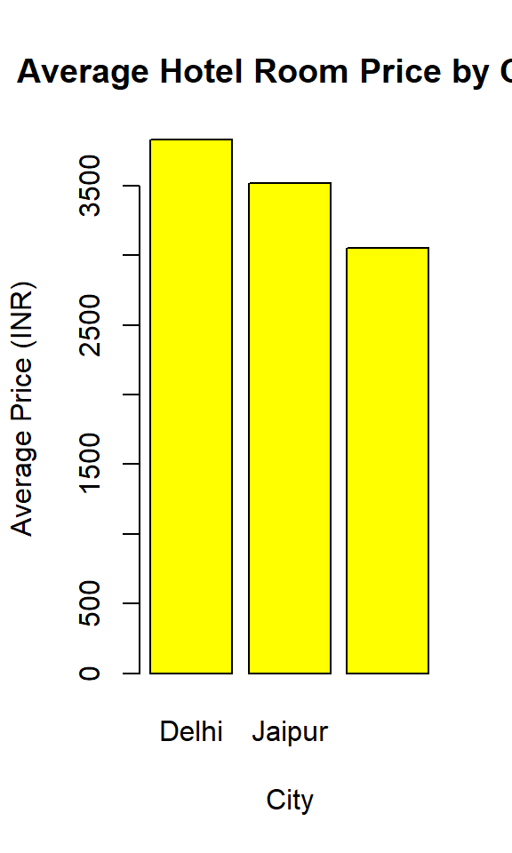

```r
barplot(
  city_prices$Average_Hotel_Room_Price_INR,
  names.arg = city_prices$City,
  col = "yellow",
  main = "Average Hotel Room Price by City",
  xlab = "City",
  ylab = "Average Price (INR)"
)
```

## 12. Domestic and International Tourist Analysis

```r
tourist_type <- data.frame(
  Tourist_Type = c("Domestic", "International"),
  Total = c(
    sum(data$Domestic_Tourist_Arrivals),
    sum(data$International_Tourist_Arrivals)
  )
)

knitr::kable(tourist_type)
```

| Tourist_Type | Total |
| --- | --- |
| Domestic | 3000000 |
| International | 575000 |

### Graph: Tourist type comparison

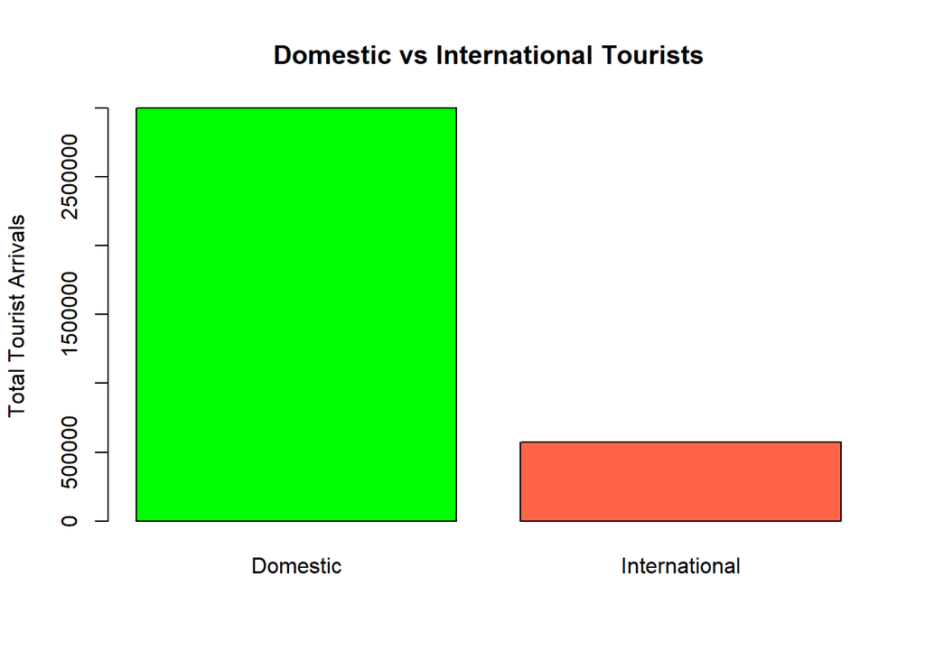

```r
barplot(
  tourist_type$Total,
  names.arg = tourist_type$Tourist_Type,
  col = c("green", "tomato"),
  main = "Domestic vs International Tourists",
  ylab = "Total Tourist Arrivals"
)
```

## 13. Relationship and Correlation Analysis

Definition: Correlation measures the strength and direction of the relationship between two numerical variables. - Positive correlation: both variables tend to increase together. - Negative correlation: one tends to decrease as the other increases. - Correlation near zero: little linear relationship.

### Scatter Plot

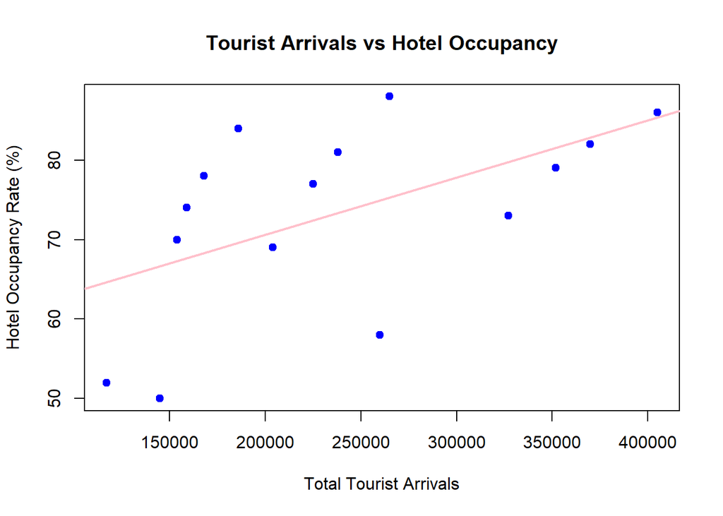

```r
plot(
  data$Total_Tourist_Arrivals,
  data$Hotel_Occupancy_Rate_Percent,
  main = "Tourist Arrivals vs Hotel Occupancy",
  xlab = "Total Tourist Arrivals",
  ylab = "Hotel Occupancy Rate (%)",
  pch = 19,
  col = "blue"
)

abline(
  lm(
    Hotel_Occupancy_Rate_Percent ~ Total_Tourist_Arrivals,
    data = data
  ),
  col = "pink",
  lwd = 2
)
```

### Correlation

```r
cor(
  data$Total_Tourist_Arrivals,
  data$Hotel_Occupancy_Rate_Percent
)
```

```
## [1] 0.5470748
```

## 14. Major Findings

```r
highest_city <- city_arrivals[
  which.max(city_arrivals$Total_Tourist_Arrivals), ]

highest_season <- season_arrivals[
  which.max(season_arrivals$Total_Tourist_Arrivals), ]

highest_occupancy <- city_occupancy[
  which.max(city_occupancy$Hotel_Occupancy_Rate_Percent), ]

highest_price <- city_prices[
  which.max(city_prices$Average_Hotel_Room_Price_INR), ]

cat("City with highest tourist arrivals:",
    highest_city$City, "\n")
```

```
## City with highest tourist arrivals: Delhi
```

```r
cat("Season with highest tourist arrivals:",
    highest_season$Season, "\n")
```

```
## Season with highest tourist arrivals: Winter
```

```r
cat("City with highest average occupancy:",
    highest_occupancy$City, "\n")
```

```
## City with highest average occupancy: Delhi
```

```r
cat("City with highest average room price:",
    highest_price$City, "\n")
```

```
## City with highest average room price: Delhi
```

## 15. Recommendations

1. Tourism departments should promote cities during periods of lower tourist arrivals.
2. Hotels should plan room availability according to seasonal demand.
3. Hotels should monitor room prices and occupancy patterns to improve their services.
4. Tourism authorities should encourage both domestic and international tourism.

## 16. Limitations

- The dataset contains only 15 observations.
- Only three cities are included.
- Only selected months of 2025 are covered.
- The dataset is a small educational sample and does not represent official tourism statistics.
- The results should not be generalised to all cities or all months.

## 17. Conclusion

This project uses descriptive analytics to study tourist arrivals and hotel occupancy dynamics in Kolkata, Delhi and Jaipur.

Statistical summaries, tables and graphical visualisations help compare tourist arrivals, seasonal patterns, hotel occupancy rates and average room prices.

The analysis provides a basic understanding of tourism demand and hotel performance. A larger official dataset covering more cities and months would support more reliable conclusions.

## 18. References and Data Source Note

Dataset: Small City Tourism and Hotel Occupancy Dataset, prepared as a synthetic educational dataset for this project.

Software: R and RStudio.

Packages: readr and knitr.

Analysis Type: Descriptive Analytics.